# Project 3: Cars4U Project

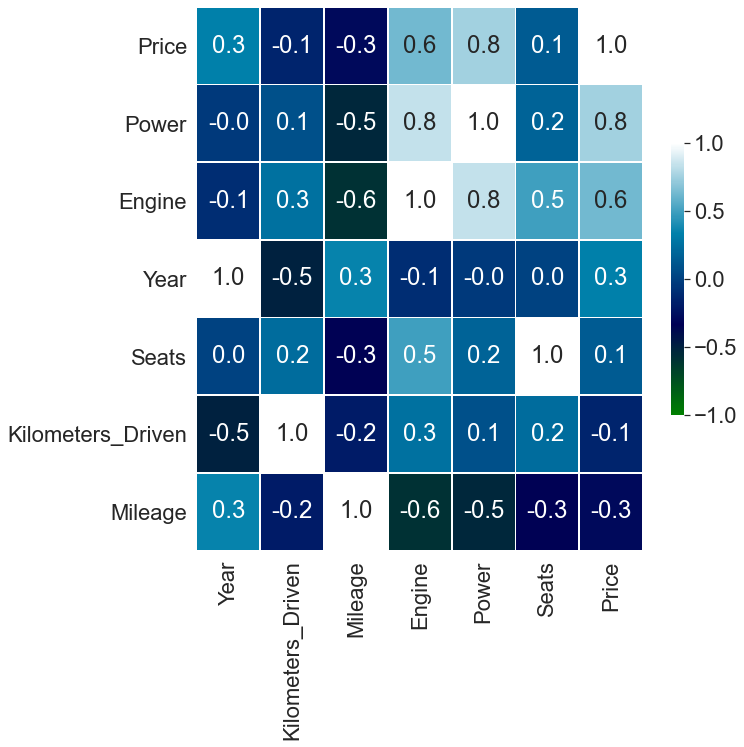

```python
# Correlation is much higher between Price/Power, as well as Price/Engine
numeric_columns = cars.select_dtypes(include=np.number).columns.tolist()
corr = (
    cars[numeric_columns].corr().sort_values(by=["Price"], ascending=False)
)

f, ax = plt.subplots(figsize=(10, 10))

sns.heatmap(
    corr,
    cmap="ocean",
    annot=True,
    fmt=".1f",
    vmin=-1,
    vmax=1,
    center=0,
    square=False,
    linewidths=0.7,
    cbar_kws={"shrink": 0.5},
)
```

After Data Treatment multicolinearity decreased, but we still need to keep an eye on it

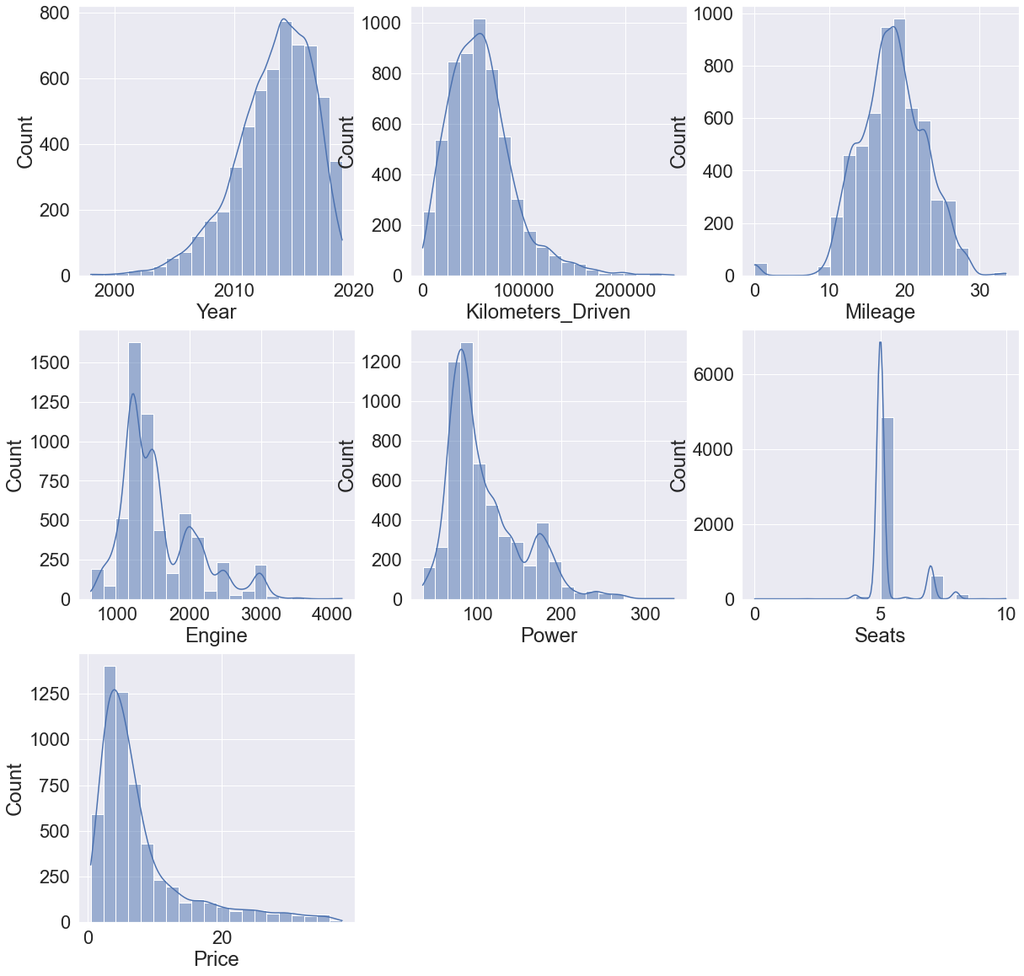

```python
all_col = cars.select_dtypes(include=np.number).columns.tolist()
#all_col.remove("Year")
plt.figure(figsize=(20, 20))

for i in range(len(all_col)):
    plt.subplot(3, 3, i + 1)
    sns.histplot(cars[all_col[i]], bins = 20, kde=True)  # you can comment the previous line and run this one to get distribution curves

plt.show()
```

After doing Data Treatment the variables have a better distribution, but still not normal distribution as they are still a bit skewed and some have huge gaps in some intervals.

[figure not shown]

```python
# We have already noticed some outliers in previous analysis, but these graphs show that almost all
plt.figure(figsize=(15, 20))

for i, variable in enumerate(numeric_columns):
    plt.subplot(4, 4, i + 1)
    plt.boxplot(cars[variable], whis=2.5)
    plt.tight_layout()
    plt.title(variable)

plt.show()
```

Here is visually clear that the number of outliers decreased

# Treating Data further

There are still some Data that can be improved to provide us more reliable information about the cars price.

```python
# Now lets drop Fourth & Above Onwer Type due to the small number of observations
cars.drop(cars[cars['Owner_Type'] == 'Fourth & Above'].index, inplace = True)
```

```python
# Now lets drop Fuel Type that have no mature market
cars.drop(cars[cars['Fuel_Type'] == 'CNG'].index, inplace = True)
cars.drop(cars[cars['Fuel_Type'] == 'LPG'].index, inplace = True)
cars.drop(cars[cars['Fuel_Type'] == 'Electric'].index, inplace = True)
```

```python
# Now lets drop the cars without seats, since it is only one observation and very rare (never seen a car without seat!).
#Cars with 9 or 10 seats may be vans or combis, which is possible.
cars.drop(cars[cars['Seats'] == 0 ].index, inplace = True)
```

```python
# Lets fill the missing Data on Power with Median to avoid distribution influences
cars['Power'].fillna(cars['Power'].median(), inplace=True)
```

```python
cars.isna().sum() # no missing data
```

```
Location             0
Year                 0
Kilometers_Driven    0
Fuel_Type            0
Transmission         0
Owner_Type           0
Mileage              0
Engine               0
Power                0
Seats                0
Price                0
Brand                0
Model                0
dtype: int64
```

```python
cars.info() # still enough observations for statistical analysis
```

```
<class 'pandas.core.frame.DataFrame'>
Int64Index: 5658 entries, 1 to 6018
Data columns (total 13 columns):
 #   Column             Non-Null Count  Dtype
---  ------             --------------  -----
 0   Location           5658 non-null   object
 1   Year               5658 non-null   int64
 2   Kilometers_Driven  5658 non-null   int64
 3   Fuel_Type          5658 non-null   object
 4   Transmission       5658 non-null   object
 5   Owner_Type         5658 non-null   object
 6   Mileage            5658 non-null   float64
 7   Engine             5658 non-null   float64
 8   Power              5658 non-null   float64
 9   Seats              5658 non-null   float64
 10  Price              5658 non-null   float64
 11  Brand              5658 non-null   object
 12  Model              5658 non-null   object
dtypes: float64(5), int64(2), object(6)
memory usage: 618.8+ KB
```

# Log Transformation of variables

Since we are still not sure if the outliers transformation will provide a quality statistical model, I will consider a second analysis including Square root transformation for some variables. I did not perform a log transformation because the variable Mileage will have an infinite warning.

```python
cars_Log = cars.copy() # save a file for log
```

```
array([[<AxesSubplot:title={'center':'sqrt'}>,
        <AxesSubplot:title={'center':'log'}>],
       [<AxesSubplot:>, <AxesSubplot:>]], dtype=object)
```

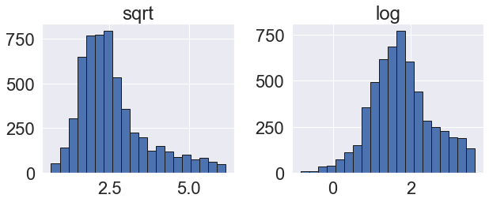

```python
Price_trans = cars_Log['Price'].transform([np.sqrt, np.log])
Price_trans.hist(bins=20, layout = (2,2), edgecolor='k', figsize=(10,8))
```

```
array([[<AxesSubplot:title={'center':'sqrt'}>,
        <AxesSubplot:title={'center':'log'}>],
       [<AxesSubplot:>, <AxesSubplot:>]], dtype=object)
```

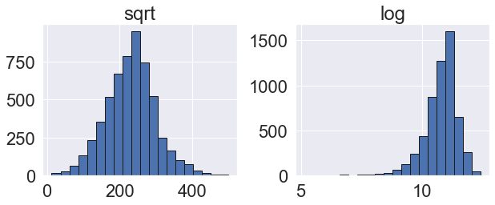

```python
KD_trans = cars_Log['Kilometers_Driven'].transform([np.sqrt, np.log])
KD_trans.hist(bins=20, layout = (2,2), edgecolor='k', figsize=(10,8))
```

```
array([[<AxesSubplot:title={'center':'sqrt'}>,
        <AxesSubplot:title={'center':'log'}>],
       [<AxesSubplot:>, <AxesSubplot:>]], dtype=object)
```

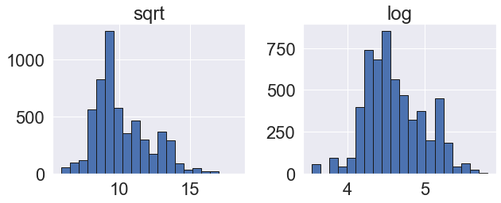

```python
Pw_trans = cars_Log['Power'].transform([np.sqrt, np.log])
Pw_trans.hist(bins=20, layout = (2,2), edgecolor='k', figsize=(10,8))
```

```
array([[<AxesSubplot:title={'center':'sqrt'}>, <AxesSubplot:>],
       [<AxesSubplot:>, <AxesSubplot:>]], dtype=object)
```

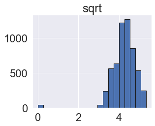

```python
Mi_trans = cars_Log['Mileage'].transform([np.sqrt])
Mi_trans.hist(bins=20, layout = (2,2), edgecolor='k', figsize=(10,8))
```

```python
cars_Log['Pricesqrt'] = cars_Log['Price'].transform([np.sqrt])
```

```python
cars_Log['KDsqrt'] = cars_Log['Kilometers_Driven'].transform([np.sqrt])
```

```python
cars_Log['MILsqrt'] = cars_Log['Mileage'].transform([np.sqrt])
```

```python
cars_Log['Pwsqrt'] = cars_Log['Power'].transform([np.sqrt])
```

```python
cars_Log.info()
```

```
<class 'pandas.core.frame.DataFrame'>
Int64Index: 5658 entries, 1 to 6018
Data columns (total 17 columns):
 #   Column             Non-Null Count  Dtype
---  ------             --------------  -----
 0   Location           5658 non-null   object
 1   Year               5658 non-null   int64
 2   Kilometers_Driven  5658 non-null   int64
 3   Fuel_Type          5658 non-null   object
 4   Transmission       5658 non-null   object
 5   Owner_Type         5658 non-null   object
 6   Mileage            5658 non-null   float64
 7   Engine             5658 non-null   float64
 8   Power              5658 non-null   float64
 9   Seats              5658 non-null   float64
 10  Price              5658 non-null   float64
 11  Brand              5658 non-null   object
 12  Model              5658 non-null   object
 13  Pricesqrt          5658 non-null   float64
 14  KDsqrt             5658 non-null   float64
 15  MILsqrt            5658 non-null   float64
 16  Pwsqrt             5658 non-null   float64
dtypes: float64(9), int64(2), object(6)
memory usage: 795.7+ KB
```

# Data Modelling without LOG Transformation

```python
# defining X and y variables
X = cars.drop(["Price",'Model'], axis=1)
y = cars[["Price"]]
print(X.shape)
print(y.shape)
```

```
(5658, 11)
(5658, 1)
```

```python
# creating dummy variables with the categorical columns
X = pd.get_dummies(X, columns=['Transmission', 'Owner_Type', 'Brand','Fuel_Type','Location'], drop_first=True)
X.head()
```

|  | Year | Kilometers_Driven | Mileage | Engine | Power | Seats | Transmission_Manual | Owner_Type_Second | Owner_Type_Third | Brand_BMW | Brand_Chevrolet | Brand_Datsun | Brand_Fiat | Brand_Ford | Brand_Honda | Brand_Hyundai | Brand_Jaguar | Brand_Jeep | Brand_Land-Rover | Brand_Mahindra | Brand_Maruti | Brand_Mercedes-Benz | Brand_Mini | Brand_Mitsubishi | Brand_Nissan | Brand_Renault | Brand_Skoda | Brand_Tata | Brand_Toyota | … |
| --- | --- | --- | --- | --- | --- | --- | --- | --- | --- | --- | --- | --- | --- | --- | --- | --- | --- | --- | --- | --- | --- | --- | --- | --- | --- | --- | --- | --- | --- | --- |
| 1 | 2015 | 41000 | 19.67 | 1582.0 | 126.20 | 5.0 | 1 | 0 | 0 | 0 | 0 | 0 | 0 | 0 | 0 | 1 | 0 | 0 | 0 | 0 | 0 | 0 | 0 | 0 | 0 | 0 | 0 | 0 | 0 | … |
| 2 | 2011 | 46000 | 18.20 | 1199.0 | 88.70 | 5.0 | 1 | 0 | 0 | 0 | 0 | 0 | 0 | 0 | 1 | 0 | 0 | 0 | 0 | 0 | 0 | 0 | 0 | 0 | 0 | 0 | 0 | 0 | 0 | … |
| 3 | 2012 | 87000 | 20.77 | 1248.0 | 88.76 | 7.0 | 1 | 0 | 0 | 0 | 0 | 0 | 0 | 0 | 0 | 0 | 0 | 0 | 0 | 0 | 1 | 0 | 0 | 0 | 0 | 0 | 0 | 0 | 0 | … |
| 4 | 2013 | 40670 | 15.20 | 1968.0 | 140.80 | 5.0 | 0 | 1 | 0 | 0 | 0 | 0 | 0 | 0 | 0 | 0 | 0 | 0 | 0 | 0 | 0 | 0 | 0 | 0 | 0 | 0 | 0 | 0 | 0 | … |
| 6 | 2013 | 86999 | 23.08 | 1461.0 | 63.10 | 5.0 | 1 | 0 | 0 | 0 | 0 | 0 | 0 | 0 | 0 | 0 | 0 | 0 | 0 | 0 | 0 | 0 | 0 | 0 | 1 | 0 | 0 | 0 | 0 | … |

```python
print(X.shape)
print(y.shape)
```

```
(5658, 42)
(5658, 1)
```

```python
# split the data into train and test
from sklearn.model_selection import train_test_split

X_train, X_test, y_train, y_test = train_test_split(
    X, y, test_size=0.3, random_state=42
)
```

# Evaluate the Model

```python
# fitting the model on the train data (70% of the whole data)
from sklearn.linear_model import LinearRegression

linearregression = LinearRegression()
linearregression.fit(X_train, y_train)
```

```
LinearRegression()
```

```python
# let us check the coefficients and intercept of the model

coef_df = pd.DataFrame(
    np.append(linearregression.coef_[0], linearregression.intercept_[0]),
    index=X_train.columns.tolist() + ["Intercept"],
    columns=["Coefficients"],
)

coef_df
```

|  | Coefficients |
| --- | --- |
| Year | 0.705487 |
| Kilometers_Driven | -0.000022 |
| Mileage | -0.173245 |
| Engine | 0.000141 |
| Power | 0.056381 |
| Seats | 0.528152 |
| Transmission_Manual | -0.993658 |
| Owner_Type_Second | -0.741388 |
| Owner_Type_Third | 0.372062 |
| Brand_BMW | -0.988175 |
| Brand_Chevrolet | -9.175734 |
| Brand_Datsun | -10.362832 |
| Brand_Fiat | -8.964508 |
| Brand_Ford | -7.628091 |
| Brand_Honda | -8.544984 |
| Brand_Hyundai | -8.305595 |
| Brand_Jaguar | 2.252079 |
| Brand_Jeep | -4.266457 |
| Brand_Land-Rover | 5.367055 |
| Brand_Mahindra | -10.208303 |
| Brand_Maruti | -7.795061 |
| Brand_Mercedes-Benz | -0.439210 |
| Brand_Mini | 7.329923 |
| Brand_Mitsubishi | -5.839490 |
| Brand_Nissan | -8.625894 |
| Brand_Renault | -8.885165 |
| Brand_Skoda | -7.950133 |
| Brand_Tata | -9.733696 |
| Brand_Toyota | -5.647216 |
| Brand_Volkswagen | -8.921742 |
| Brand_Volvo | -2.794132 |
| Fuel_Type_Petrol | -2.021342 |
| Location_Bangalore | 1.004373 |
| Location_Chennai | 0.453884 |
| Location_Coimbatore | 1.135244 |
| Location_Delhi | -0.597283 |
| Location_Hyderabad | 1.087681 |
| Location_Jaipur | 0.487434 |
| Location_Kochi | -0.140865 |
| Location_Kolkata | -1.505962 |
| Location_Mumbai | -0.852207 |
| Location_Pune | 0.179066 |
| Intercept | -1408.260352 |

```python
# defining function for MAPE
def mape(targets, predictions):
    return np.mean(np.abs((targets - predictions)) / targets) * 100


# defining common function for all metrics
def model_perf(model, inp, out):
    """
    model: model
    inp: independent variables
    out: dependent variable
    """
    y_pred = model.predict(inp).flatten()
    y_act = out.values.flatten()

    return pd.DataFrame(
        {
            "MAE": mean_absolute_error(y_act, y_pred),
            "MAPE": mape(y_act, y_pred),
            "RMSE": np.sqrt(mean_squared_error(y_act, y_pred)),
            "R^2": r2_score(y_act, y_pred),
        },
        index=[0],
    )
```

```python
# Checking model performance on train set (seen 70% data)
print("Train Performance\n")
model_perf(linearregression, X_train, y_train)
```

```
Train Performance
```

|  | MAE | MAPE | RMSE | R^2 |
| --- | --- | --- | --- | --- |
| 0 | 1.932717 | 41.678051 | 2.937247 | 0.839325 |

```python
# Checking model performance on test set (unseen 30% data)
print("Test Performance\n")
model_perf(linearregression, X_test, y_test)
```

```
Test Performance
```

|  | MAE | MAPE | RMSE | R^2 |
| --- | --- | --- | --- | --- |
| 0 | 1.926798 | 42.765481 | 2.894896 | 0.819947 |

**Observations**

- The training and testing scores are 84% and 82% respectively, and both the scores are comparable. Hence, the model is a good fit.
- R-squared is 0.82 on the test set, i.e., the model explains 82% of total variation in the test dataset. So, overall the model is very satisfactory.
- MAE indicates that our current model is able to predict Prices within a mean error of 1.9 INR Lakhs.
- MAPE value is very high, since predicted values have high variance. This issue implies that the MAPE should be used carefully if there are extremely small observations and directly motivates the last and often ignored the weakness of the MAPE.

# Linear Regression with Statsmodel

```python
# Let's build linear regression model using statsmodel
# unlike sklearn, statsmodels does not add a constant to the data on its own
# we have to add the constant manually
X = sm.add_constant(X)
X_train1, X_test, y_train, y_test = train_test_split(
    X, y, test_size=0.3, random_state=42
)

olsmod0 = sm.OLS(y_train, X_train1)
olsres0 = olsmod0.fit()
print(olsres0.summary())
```

```
                            OLS Regression Results
==============================================================================
Dep. Variable:                  Price   R-squared:                       0.839
Model:                            OLS   Adj. R-squared:                  0.838
Method:                 Least Squares   F-statistic:                     487.2
Date:                Fri, 18 Jun 2021   Prob (F-statistic):               0.00
Time:                        11:59:45   Log-Likelihood:                -9885.8
No. Observations:                3960   AIC:                         1.986e+04
Df Residuals:                    3917   BIC:                         2.013e+04
Df Model:                          42
Covariance Type:            nonrobust
=======================================================================================
                          coef    std err          t      P>|t|      [0.025      0.975]
---------------------------------------------------------------------------------------
const               -1408.2604     42.578    -33.075      0.000   -1491.737   -1324.784
Year                    0.7055      0.021     33.231      0.000       0.664       0.747
Kilometers_Driven   -2.163e-05   1.97e-06    -10.958      0.000   -2.55e-05   -1.78e-05
Mileage                -0.1732      0.020     -8.815      0.000      -0.212      -0.135
Engine                  0.0001      0.000      0.506      0.613      -0.000       0.001
Power                   0.0564      0.003     18.672      0.000       0.050       0.062
Seats                   0.5282      0.101      5.236      0.000       0.330       0.726
Transmission_Manual    -0.9937      0.154     -6.465      0.000      -1.295      -0.692
Owner_Type_Second      -0.7414      0.140     -5.297      0.000      -1.016      -0.467
Owner_Type_Third        0.3721      0.378      0.983      0.326      -0.370       1.114
Brand_BMW              -0.9882      0.357     -2.767      0.006      -1.688      -0.288
Brand_Chevrolet        -9.1757      0.462    -19.857      0.000     -10.082      -8.270
Brand_Datsun          -10.3628      1.057     -9.804      0.000     -12.435      -8.291
Brand_Fiat             -8.9645      0.789    -11.367      0.000     -10.511      -7.418
Brand_Ford             -7.6281      0.378    -20.158      0.000      -8.370      -6.886
Brand_Honda            -8.5450      0.345    -24.793      0.000      -9.221      -7.869
Brand_Hyundai          -8.3056      0.336    -24.718      0.000      -8.964      -7.647
Brand_Jaguar            2.2521      0.734      3.068      0.002       0.813       3.691
Brand_Jeep             -4.2665      0.983     -4.339      0.000      -6.194      -2.339
Brand_Land-Rover        5.3671      0.667      8.047      0.000       4.059       6.675
Brand_Mahindra        -10.2083      0.418    -24.401      0.000     -11.029      -9.388
Brand_Maruti           -7.7951      0.354    -22.046      0.000      -8.488      -7.102
Brand_Mercedes-Benz    -0.4392      0.344     -1.276      0.202      -1.114       0.236
Brand_Mini              7.3299      0.688     10.654      0.000       5.981       8.679
Brand_Mitsubishi       -5.8395      0.720     -8.107      0.000      -7.252      -4.427
Brand_Nissan           -8.6259      0.492    -17.527      0.000      -9.591      -7.661
```

[output cut: 13 more lines]

```
Location_Kochi         -0.1409      0.284     -0.495      0.620      -0.699       0.417
Location_Kolkata       -1.5060      0.290     -5.199      0.000      -2.074      -0.938
Location_Mumbai        -0.8522      0.275     -3.094      0.002      -1.392      -0.312
Location_Pune           0.1791      0.285      0.629      0.530      -0.379       0.737
==============================================================================
Omnibus:                      658.487   Durbin-Watson:                   1.940
Prob(Omnibus):                  0.000   Jarque-Bera (JB):             3973.769
Skew:                           0.651   Prob(JB):                         0.00
Kurtosis:                       7.732   Cond. No.                     5.93e+07
==============================================================================

Notes:
[1] Standard Errors assume that the covariance matrix of the errors is correctly specified.
[2] The condition number is large, 5.93e+07. This might indicate that there are
strong multicollinearity or other numerical problems.
```

**Observations**

- There are more Negative values of the coefficient tha positive.
- Negative values of the coefficient show that *Price* decreases with the increase of corresponding attribute value.
- In the entire set there are few attributes with p-value > 0.05. Hence, most attributes have p-value < 0.05 and are considered significant.
- Lets check multicollinearity, which will affect the p-values.

# Checking Linear Regression Assumptions

TEST FOR MULTICOLLINEARITY

```python
from statsmodels.stats.outliers_influence import variance_inflation_factor

Multicol = pd.Series(
    [variance_inflation_factor(X.values, i) for i in range(X.shape[1])], index=X.columns
)
print("VIF Scores: \n\n{}\n".format(Multicol))
```

```
VIF Scores:

const                  820637.579407
Year                        2.138607
Kilometers_Driven           1.861442
Mileage                     3.278528
Engine                      9.639843
Power                       7.769471
Seats                       2.730576
Transmission_Manual         2.122998
Owner_Type_Second           1.177195
Owner_Type_Third            1.115738
Brand_BMW                   2.082513
Brand_Chevrolet             1.958091
Brand_Datsun                1.148364
Brand_Fiat                  1.207019
Brand_Ford                  3.194269
Brand_Honda                 5.049572
Brand_Hyundai               7.908655
Brand_Jaguar                1.149792
Brand_Jeep                  1.110532
Brand_Land-Rover            1.204745
Brand_Mahindra              3.550002
Brand_Maruti                9.079315
Brand_Mercedes-Benz         2.194496
Brand_Mini                  1.145185
Brand_Mitsubishi            1.239369
Brand_Nissan                1.723342
Brand_Renault               2.134358
Brand_Skoda                 2.023442
Brand_Tata                  2.516675
Brand_Toyota                4.370506
Brand_Volkswagen            3.245778
Brand_Volvo                 1.107948
Fuel_Type_Petrol            2.654950
Location_Bangalore          2.380445
Location_Chennai            2.960749
Location_Coimbatore         3.318435
Location_Delhi              3.101561
Location_Hyderabad          3.754183
Location_Jaipur             2.683096
Location_Kochi              3.480809
Location_Kolkata            3.117152
Location_Mumbai             3.855480
Location_Pune               3.372397
dtype: float64
```

### Delete VIF for non dummy variables higher than 5

```python
# As we have mentioned several times, Engine is highly correlated to Power, therefore to price. This overfits the model. We need to delete the variable.
X_train2 = X_train1.drop("Engine", axis=1)

Multicol2 = pd.Series(
    [variance_inflation_factor(X_train2.values, i) for i in range(X_train2.shape[1])],
    index=X_train2.columns,
)
print("VIF Scores: \n\n{}\n".format(Multicol2))
```

```
VIF Scores:

const                  818387.901824
Year                        2.129344
Kilometers_Driven           1.852256
Mileage                     2.976541
Power                       4.087761
Seats                       2.532663
Transmission_Manual         2.097482
Owner_Type_Second           1.183828
Owner_Type_Third            1.129327
Brand_BMW                   2.149221
Brand_Chevrolet             1.964992
Brand_Datsun                1.149590
Brand_Fiat                  1.206727
Brand_Ford                  3.220964
Brand_Honda                 4.948242
Brand_Hyundai               8.061021
Brand_Jaguar                1.168009
Brand_Jeep                  1.104928
Brand_Land-Rover            1.215493
Brand_Mahindra              3.560478
Brand_Maruti                9.101234
Brand_Mercedes-Benz         2.227251
Brand_Mini                  1.184366
Brand_Mitsubishi            1.235599
Brand_Nissan                1.701362
Brand_Renault               2.222439
Brand_Skoda                 1.911869
Brand_Tata                  2.537819
Brand_Toyota                3.965603
Brand_Volkswagen            3.255961
Brand_Volvo                 1.113706
Fuel_Type_Petrol            2.260846
Location_Bangalore          2.383815
Location_Chennai            3.066121
Location_Coimbatore         3.323293
Location_Delhi              3.181928
Location_Hyderabad          3.787222
Location_Jaipur             2.753289
Location_Kochi              3.490314
Location_Kolkata            3.109223
Location_Mumbai             3.922088
Location_Pune               3.381029
dtype: float64
```

```python
# no changes in the statistical values
olsmod1 = sm.OLS(y_train, X_train2)
olsres1 = olsmod1.fit()
print(olsres1.summary())
```

```
                            OLS Regression Results
==============================================================================
Dep. Variable:                  Price   R-squared:                       0.839
Model:                            OLS   Adj. R-squared:                  0.838
Method:                 Least Squares   F-statistic:                     499.1
Date:                Fri, 18 Jun 2021   Prob (F-statistic):               0.00
Time:                        11:59:52   Log-Likelihood:                -9885.9
No. Observations:                3960   AIC:                         1.986e+04
Df Residuals:                    3918   BIC:                         2.012e+04
Df Model:                          41
Covariance Type:            nonrobust
=======================================================================================
                          coef    std err          t      P>|t|      [0.025      0.975]
---------------------------------------------------------------------------------------
const               -1406.6365     42.452    -33.134      0.000   -1489.867   -1323.406
Year                    0.7047      0.021     33.283      0.000       0.663       0.746
Kilometers_Driven   -2.159e-05   1.97e-06    -10.948      0.000   -2.55e-05   -1.77e-05
Mileage                -0.1763      0.019     -9.435      0.000      -0.213      -0.140
Power                   0.0575      0.002     26.917      0.000       0.053       0.062
Seats                   0.5434      0.096      5.646      0.000       0.355       0.732
Transmission_Manual    -0.9956      0.154     -6.480      0.000      -1.297      -0.694
Owner_Type_Second      -0.7415      0.140     -5.298      0.000      -1.016      -0.467
Owner_Type_Third        0.3709      0.378      0.980      0.327      -0.371       1.113
Brand_BMW              -0.9926      0.357     -2.781      0.005      -1.692      -0.293
Brand_Chevrolet        -9.1708      0.462    -19.853      0.000     -10.076      -8.265
Brand_Datsun          -10.3502      1.057     -9.796      0.000     -12.422      -8.279
Brand_Fiat             -8.9711      0.788    -11.378      0.000     -10.517      -7.425
Brand_Ford             -7.6025      0.375    -20.274      0.000      -8.338      -6.867
Brand_Honda            -8.5263      0.343    -24.884      0.000      -9.198      -7.855
Brand_Hyundai          -8.2981      0.336    -24.722      0.000      -8.956      -7.640
Brand_Jaguar            2.2569      0.734      3.075      0.002       0.818       3.696
Brand_Jeep             -4.2787      0.983     -4.353      0.000      -6.206      -2.352
Brand_Land-Rover        5.3769      0.667      8.066      0.000       4.070       6.684
Brand_Mahindra        -10.1791      0.414    -24.569      0.000     -10.991      -9.367
Brand_Maruti           -7.7878      0.353    -22.046      0.000      -8.480      -7.095
Brand_Mercedes-Benz    -0.4228      0.343     -1.234      0.217      -1.095       0.249
Brand_Mini              7.3470      0.687     10.693      0.000       6.000       8.694
Brand_Mitsubishi       -5.7576      0.702     -8.204      0.000      -7.133      -4.382
Brand_Nissan           -8.5989      0.489    -17.578      0.000      -9.558      -7.640
Brand_Renault          -8.8755      0.430    -20.664      0.000      -9.718      -8.033
```

[output cut: 12 more lines]

```
Location_Kochi         -0.1395      0.284     -0.490      0.624      -0.697       0.418
Location_Kolkata       -1.5064      0.290     -5.201      0.000      -2.074      -0.938
Location_Mumbai        -0.8507      0.275     -3.089      0.002      -1.391      -0.311
Location_Pune           0.1798      0.285      0.632      0.528      -0.378       0.738
==============================================================================
Omnibus:                      660.930   Durbin-Watson:                   1.940
Prob(Omnibus):                  0.000   Jarque-Bera (JB):             3964.374
Skew:                           0.656   Prob(JB):                         0.00
Kurtosis:                       7.723   Cond. No.                     5.91e+07
==============================================================================

Notes:
[1] Standard Errors assume that the covariance matrix of the errors is correctly specified.
[2] The condition number is large, 5.91e+07. This might indicate that there are
strong multicollinearity or other numerical problems.
```

**Observations**

There are no significant changes from the previous observations.

# Check mean of residuals

### mean of residuals is very close to zero

```python
residual = olsres1.resid
np.mean(residual)
```

```
-5.180689771678299e-12
```

# Test Linearity

### the model is showing signs of non-linearity

=> Log Transformation did not improve the situation (tested but not included), while Sqrt Transformation only a bit (still very curvy).

```python
residual = olsres1.resid
fitted = olsres1.fittedvalues  # predicted values
```

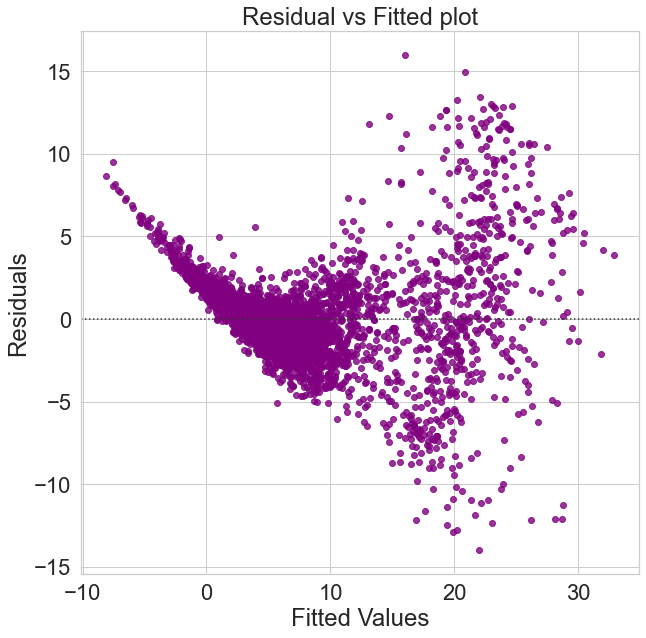

```python
sns.set_style("whitegrid")
plt.figure(figsize=(10, 10))
sns.residplot(fitted, residual, color="purple", lowess=False)
plt.xlabel("Fitted Values")
plt.ylabel("Residuals")
plt.title("Residual vs Fitted plot")
plt.show()
```

```python
res_sqrt = np.sqrt(residual)
fit_sqrt = np.sqrt(fitted)
```

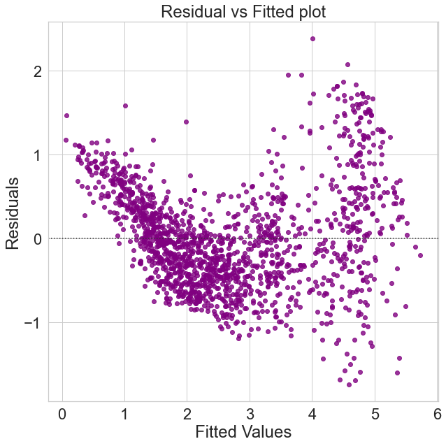

```python
sns.set_style("whitegrid")
plt.figure(figsize=(10, 10))
sns.residplot(fit_sqrt, res_sqrt, color="purple", lowess=False)
plt.xlabel("Fitted Values")
plt.ylabel("Residuals")
plt.title("Residual vs Fitted plot")
plt.show()
```

# Test for normality

### Error terms/Residuals normally distributed

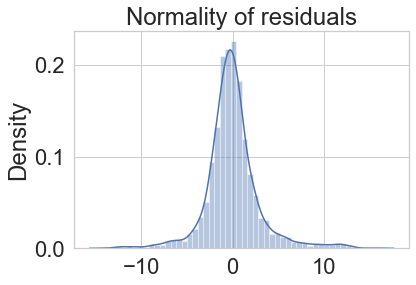

```python
sns.distplot(residual)
plt.title("Normality of residuals")
plt.show()
```

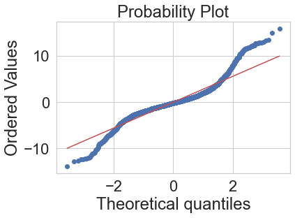

```python
import pylab
import scipy.stats as stats

stats.probplot(residual, dist="norm", plot=pylab)
plt.show()
```

```python
stats.shapiro(residual)
```

```
ShapiroResult(statistic=0.9024742841720581, pvalue=9.80908925027372e-45)
```

The residuals are not normal as per shapiro test, but as per QQ plot and distplot they are approximately normal.

QQ plot shows between invertal -2,2 that the data behaves pretty normal, the deviations start by the values above those thresholds.

The higher variances outside of range -2 , 2 may have influenced shapiro test. Because in big data sets, even for small deviations, shapiro shows as not normal.

Hence we go with the plots and say that residuals are normal.

# Test for Homoscedasticity

```python
import statsmodels.stats.api as sms
from statsmodels.compat import lzip

name = ["F statistic", "p-value"]
test = sms.het_goldfeldquandt(residual, X_train2)
lzip(name, test)
```

```
[('F statistic', 0.9666878254258191), ('p-value', 0.7720525508026277)]
```

Since p-value > 0.05, we can say that the residuals are homoscedastic (variance of the residuals are symmetrically distributed across the regression line). This assumption is therefore valid in the data.

# Predicting on the test data without sqrt transformation

```python
X_train2.columns
X_train2.shape
```

```
(3960, 42)
```

```python
X_test_final = X_test[X_train2.columns]
```

```python
X_test_final.head()
```

|  | const | Year | Kilometers_Driven | Mileage | Power | Seats | Transmission_Manual | Owner_Type_Second | Owner_Type_Third | Brand_BMW | Brand_Chevrolet | Brand_Datsun | Brand_Fiat | Brand_Ford | Brand_Honda | Brand_Hyundai | Brand_Jaguar | Brand_Jeep | Brand_Land-Rover | Brand_Mahindra | Brand_Maruti | Brand_Mercedes-Benz | Brand_Mini | Brand_Mitsubishi | Brand_Nissan | Brand_Renault | Brand_Skoda | Brand_Tata | Brand_Toyota | … |
| --- | --- | --- | --- | --- | --- | --- | --- | --- | --- | --- | --- | --- | --- | --- | --- | --- | --- | --- | --- | --- | --- | --- | --- | --- | --- | --- | --- | --- | --- | --- |
| 4053 | 1.0 | 2006 | 44000 | 16.40 | 78.0 | 5.0 | 0 | 0 | 0 | 0 | 0 | 0 | 0 | 0 | 1 | 0 | 0 | 0 | 0 | 0 | 0 | 0 | 0 | 0 | 0 | 0 | 0 | 0 | 0 | … |
| 5424 | 1.0 | 2013 | 62188 | 17.20 | 53.5 | 5.0 | 1 | 0 | 0 | 0 | 0 | 0 | 0 | 0 | 0 | 0 | 0 | 0 | 0 | 0 | 0 | 0 | 0 | 0 | 0 | 0 | 0 | 1 | 0 | … |
| 3936 | 1.0 | 2013 | 95500 | 20.54 | 103.6 | 5.0 | 1 | 0 | 0 | 0 | 0 | 0 | 0 | 0 | 0 | 0 | 0 | 0 | 0 | 0 | 0 | 0 | 0 | 0 | 0 | 0 | 0 | 0 | 0 | … |
| 1604 | 1.0 | 2009 | 89000 | 12.50 | 147.9 | 7.0 | 0 | 0 | 0 | 0 | 1 | 0 | 0 | 0 | 0 | 0 | 0 | 0 | 0 | 0 | 0 | 0 | 0 | 0 | 0 | 0 | 0 | 0 | 0 | … |
| 3524 | 1.0 | 2015 | 63310 | 28.40 | 74.0 | 5.0 | 1 | 0 | 0 | 0 | 0 | 0 | 0 | 0 | 0 | 0 | 0 | 0 | 0 | 0 | 1 | 0 | 0 | 0 | 0 | 0 | 0 | 0 | 0 | … |

```python
X_test_final.shape
```

```
(1698, 42)
```

```python
# Checking model performance on train set (seen 70% data)
print("Train Performance\n")
model_perf(olsres1, X_train2.values, y_train)
```

```
Train Performance
```

|  | MAE | MAPE | RMSE | R^2 |
| --- | --- | --- | --- | --- |
| 0 | 1.9336 | 41.684393 | 2.937342 | 0.839314 |

```python
# Checking model performance on test set (seen 70% data)
print("Test Performance\n")
model_perf(olsres1, X_test_final.values, y_test)
```

```
Test Performance
```

|  | MAE | MAPE | RMSE | R^2 |
| --- | --- | --- | --- | --- |
| 0 | 1.927744 | 42.78161 | 2.895636 | 0.819855 |

Now we can see that the model has low test and train RMSE and MAE, and both the errors are comparable. So, our model is not suffering from overfitting.

The model is able to explain 82% of the variation on the test set, which is very good.

The MAPE on the test is very high, which implies that the MAPE should be used carefully if there are extremely small observations (which is the case since we did not transform data).

```python
# let us print the model summary

olsmod1 = sm.OLS(y_train, X_train2)
olsres1 = olsmod1.fit()
print(olsres1.summary())
```

```
                            OLS Regression Results
==============================================================================
Dep. Variable:                  Price   R-squared:                       0.839
Model:                            OLS   Adj. R-squared:                  0.838
Method:                 Least Squares   F-statistic:                     499.1
Date:                Fri, 18 Jun 2021   Prob (F-statistic):               0.00
Time:                        11:59:58   Log-Likelihood:                -9885.9
No. Observations:                3960   AIC:                         1.986e+04
Df Residuals:                    3918   BIC:                         2.012e+04
Df Model:                          41
Covariance Type:            nonrobust
=======================================================================================
                          coef    std err          t      P>|t|      [0.025      0.975]
---------------------------------------------------------------------------------------
const               -1406.6365     42.452    -33.134      0.000   -1489.867   -1323.406
Year                    0.7047      0.021     33.283      0.000       0.663       0.746
Kilometers_Driven   -2.159e-05   1.97e-06    -10.948      0.000   -2.55e-05   -1.77e-05
Mileage                -0.1763      0.019     -9.435      0.000      -0.213      -0.140
Power                   0.0575      0.002     26.917      0.000       0.053       0.062
Seats                   0.5434      0.096      5.646      0.000       0.355       0.732
Transmission_Manual    -0.9956      0.154     -6.480      0.000      -1.297      -0.694
Owner_Type_Second      -0.7415      0.140     -5.298      0.000      -1.016      -0.467
Owner_Type_Third        0.3709      0.378      0.980      0.327      -0.371       1.113
Brand_BMW              -0.9926      0.357     -2.781      0.005      -1.692      -0.293
Brand_Chevrolet        -9.1708      0.462    -19.853      0.000     -10.076      -8.265
Brand_Datsun          -10.3502      1.057     -9.796      0.000     -12.422      -8.279
Brand_Fiat             -8.9711      0.788    -11.378      0.000     -10.517      -7.425
Brand_Ford             -7.6025      0.375    -20.274      0.000      -8.338      -6.867
Brand_Honda            -8.5263      0.343    -24.884      0.000      -9.198      -7.855
Brand_Hyundai          -8.2981      0.336    -24.722      0.000      -8.956      -7.640
Brand_Jaguar            2.2569      0.734      3.075      0.002       0.818       3.696
Brand_Jeep             -4.2787      0.983     -4.353      0.000      -6.206      -2.352
Brand_Land-Rover        5.3769      0.667      8.066      0.000       4.070       6.684
Brand_Mahindra        -10.1791      0.414    -24.569      0.000     -10.991      -9.367
Brand_Maruti           -7.7878      0.353    -22.046      0.000      -8.480      -7.095
Brand_Mercedes-Benz    -0.4228      0.343     -1.234      0.217      -1.095       0.249
Brand_Mini              7.3470      0.687     10.693      0.000       6.000       8.694
Brand_Mitsubishi       -5.7576      0.702     -8.204      0.000      -7.133      -4.382
Brand_Nissan           -8.5989      0.489    -17.578      0.000      -9.558      -7.640
Brand_Renault          -8.8755      0.430    -20.664      0.000      -9.718      -8.033
```

[output cut: 12 more lines]

```
Location_Kochi         -0.1395      0.284     -0.490      0.624      -0.697       0.418
Location_Kolkata       -1.5064      0.290     -5.201      0.000      -2.074      -0.938
Location_Mumbai        -0.8507      0.275     -3.089      0.002      -1.391      -0.311
Location_Pune           0.1798      0.285      0.632      0.528      -0.378       0.738
==============================================================================
Omnibus:                      660.930   Durbin-Watson:                   1.940
Prob(Omnibus):                  0.000   Jarque-Bera (JB):             3964.374
Skew:                           0.656   Prob(JB):                         0.00
Kurtosis:                       7.723   Cond. No.                     5.91e+07
==============================================================================

Notes:
[1] Standard Errors assume that the covariance matrix of the errors is correctly specified.
[2] The condition number is large, 5.91e+07. This might indicate that there are
strong multicollinearity or other numerical problems.
```

# **Because the Model with Sqrt transformation is more reliable, I will take conclusions from them**

# Data Modelling with SQRT Transformation

```python
# This is an Squared Root Model, not a Log Model (nomenclature wrong).
Xl = cars_Log.drop(["Price",'Model', 'Pricesqrt', 'KDsqrt', 'MILsqrt', 'Pwsqrt', 'Engine'], axis=1)
yl = cars_Log[["Pricesqrt"]]
print(Xl.shape)
print(yl.shape)
```

```
(5658, 10)
(5658, 1)
```

```python
# creating dummy variables with the categorical columns
Xl = pd.get_dummies(Xl, columns=['Transmission', 'Owner_Type', 'Brand','Fuel_Type','Location'], drop_first=True)
Xl.head()
```

|  | Year | Kilometers_Driven | Mileage | Power | Seats | Transmission_Manual | Owner_Type_Second | Owner_Type_Third | Brand_BMW | Brand_Chevrolet | Brand_Datsun | Brand_Fiat | Brand_Ford | Brand_Honda | Brand_Hyundai | Brand_Jaguar | Brand_Jeep | Brand_Land-Rover | Brand_Mahindra | Brand_Maruti | Brand_Mercedes-Benz | Brand_Mini | Brand_Mitsubishi | Brand_Nissan | Brand_Renault | Brand_Skoda | Brand_Tata | Brand_Toyota | Brand_Volkswagen | … |
| --- | --- | --- | --- | --- | --- | --- | --- | --- | --- | --- | --- | --- | --- | --- | --- | --- | --- | --- | --- | --- | --- | --- | --- | --- | --- | --- | --- | --- | --- | --- |
| 1 | 2015 | 41000 | 19.67 | 126.20 | 5.0 | 1 | 0 | 0 | 0 | 0 | 0 | 0 | 0 | 0 | 1 | 0 | 0 | 0 | 0 | 0 | 0 | 0 | 0 | 0 | 0 | 0 | 0 | 0 | 0 | … |
| 2 | 2011 | 46000 | 18.20 | 88.70 | 5.0 | 1 | 0 | 0 | 0 | 0 | 0 | 0 | 0 | 1 | 0 | 0 | 0 | 0 | 0 | 0 | 0 | 0 | 0 | 0 | 0 | 0 | 0 | 0 | 0 | … |
| 3 | 2012 | 87000 | 20.77 | 88.76 | 7.0 | 1 | 0 | 0 | 0 | 0 | 0 | 0 | 0 | 0 | 0 | 0 | 0 | 0 | 0 | 1 | 0 | 0 | 0 | 0 | 0 | 0 | 0 | 0 | 0 | … |
| 4 | 2013 | 40670 | 15.20 | 140.80 | 5.0 | 0 | 1 | 0 | 0 | 0 | 0 | 0 | 0 | 0 | 0 | 0 | 0 | 0 | 0 | 0 | 0 | 0 | 0 | 0 | 0 | 0 | 0 | 0 | 0 | … |
| 6 | 2013 | 86999 | 23.08 | 63.10 | 5.0 | 1 | 0 | 0 | 0 | 0 | 0 | 0 | 0 | 0 | 0 | 0 | 0 | 0 | 0 | 0 | 0 | 0 | 0 | 1 | 0 | 0 | 0 | 0 | 0 | … |

```python
# split the data into train and test
from sklearn.model_selection import train_test_split

Xl_train, Xl_test, yl_train, yl_test = train_test_split(
    Xl, yl, test_size=0.3, random_state=42
)
```

```python
# fitting the model on the train data (70% of the whole data)
from sklearn.linear_model import LinearRegression

linearregression = LinearRegression()
linearregression.fit(Xl_train, yl_train)
```

```
LinearRegression()
```

```python
# defining function for MAPE
def mape(targets, predictions):
    return np.mean(np.abs((targets - predictions)) / targets) * 100


# defining common function for all metrics
def model_perf(model, inp, out):
    """
    model: model
    inp: independent variables
    out: dependent variable
    """
    y_pred = model.predict(inp).flatten()
    y_act = out.values.flatten()

    return pd.DataFrame(
        {
            "MAE": mean_absolute_error(y_act, y_pred),
            "MAPE": mape(y_act, y_pred),
            "RMSE": np.sqrt(mean_squared_error(y_act, y_pred)),
            "R^2": r2_score(y_act, y_pred),
        },
        index=[0],
    )
```

```python
# Checking model performance on train set (seen 70% data)
print("Train Performance\n")
model_perf(linearregression, Xl_train, yl_train)
```

```
Train Performance
```

|  | MAE | MAPE | RMSE | R^2 |
| --- | --- | --- | --- | --- |
| 0 | 0.246406 | 10.396818 | 0.337234 | 0.906172 |

```python
# Checking model performance on test set (unseen 30% data)
print("Test Performance\n")
model_perf(linearregression, Xl_test, yl_test)
```

```
Test Performance
```

|  | MAE | MAPE | RMSE | R^2 |
| --- | --- | --- | --- | --- |
| 0 | 0.249295 | 10.564485 | 0.346202 | 0.891399 |

```python
# Let's build linear regression model using statsmodel
# unlike sklearn, statsmodels does not add a constant to the data on its own
# we have to add the constant manually
Xl = sm.add_constant(Xl)
Xl_train1, Xl_test, yl_train, yl_test = train_test_split(
    Xl, yl, test_size=0.3, random_state=42
)

olsmodl = sm.OLS(yl_train, Xl_train1)
olsresl = olsmodl.fit()
print(olsresl.summary())
```

```
                            OLS Regression Results
==============================================================================
Dep. Variable:              Pricesqrt   R-squared:                       0.906
Model:                            OLS   Adj. R-squared:                  0.905
Method:                 Least Squares   F-statistic:                     922.9
Date:                Fri, 18 Jun 2021   Prob (F-statistic):               0.00
Time:                        12:00:00   Log-Likelihood:                -1314.6
No. Observations:                3960   AIC:                             2713.
Df Residuals:                    3918   BIC:                             2977.
Df Model:                          41
Covariance Type:            nonrobust
=======================================================================================
                          coef    std err          t      P>|t|      [0.025      0.975]
---------------------------------------------------------------------------------------
const                -264.7082      4.874    -54.311      0.000    -274.264    -255.153
Year                    0.1329      0.002     54.674      0.000       0.128       0.138
Kilometers_Driven   -2.737e-06   2.26e-07    -12.091      0.000   -3.18e-06   -2.29e-06
Mileage                -0.0243      0.002    -11.313      0.000      -0.028      -0.020
Power                   0.0098      0.000     39.812      0.000       0.009       0.010
Seats                   0.0901      0.011      8.154      0.000       0.068       0.112
Transmission_Manual    -0.1552      0.018     -8.797      0.000      -0.190      -0.121
Owner_Type_Second      -0.1064      0.016     -6.624      0.000      -0.138      -0.075
Owner_Type_Third       -0.0256      0.043     -0.589      0.556      -0.111       0.060
Brand_BMW              -0.1305      0.041     -3.185      0.001      -0.211      -0.050
Brand_Chevrolet        -1.3113      0.053    -24.726      0.000      -1.415      -1.207
Brand_Datsun           -1.5038      0.121    -12.397      0.000      -1.742      -1.266
Brand_Fiat             -1.2498      0.091    -13.807      0.000      -1.427      -1.072
Brand_Ford             -0.9970      0.043    -23.157      0.000      -1.081      -0.913
Brand_Honda            -1.0384      0.039    -26.396      0.000      -1.116      -0.961
Brand_Hyundai          -1.0441      0.039    -27.094      0.000      -1.120      -0.969
Brand_Jaguar            0.0377      0.084      0.447      0.655      -0.128       0.203
Brand_Jeep             -0.5458      0.113     -4.837      0.000      -0.767      -0.325
Brand_Land-Rover        0.5639      0.077      7.369      0.000       0.414       0.714
Brand_Mahindra         -1.2768      0.048    -26.843      0.000      -1.370      -1.184
Brand_Maruti           -0.9916      0.041    -24.449      0.000      -1.071      -0.912
Brand_Mercedes-Benz    -0.0445      0.039     -1.131      0.258      -0.122       0.033
Brand_Mini              0.9124      0.079     11.566      0.000       0.758       1.067
Brand_Mitsubishi       -0.5894      0.081     -7.315      0.000      -0.747      -0.431
Brand_Nissan           -1.0760      0.056    -19.158      0.000      -1.186      -0.966
Brand_Renault          -1.1155      0.049    -22.620      0.000      -1.212      -1.019
```

[output cut: 12 more lines]

```
Location_Kochi         -0.0269      0.033     -0.825      0.409      -0.091       0.037
Location_Kolkata       -0.2833      0.033     -8.519      0.000      -0.349      -0.218
Location_Mumbai        -0.1052      0.032     -3.326      0.001      -0.167      -0.043
Location_Pune          -0.0056      0.033     -0.172      0.863      -0.070       0.058
==============================================================================
Omnibus:                      248.990   Durbin-Watson:                   1.968
Prob(Omnibus):                  0.000   Jarque-Bera (JB):             1134.715
Skew:                          -0.022   Prob(JB):                    3.98e-247
Kurtosis:                       5.622   Cond. No.                     5.91e+07
==============================================================================

Notes:
[1] Standard Errors assume that the covariance matrix of the errors is correctly specified.
[2] The condition number is large, 5.91e+07. This might indicate that there are
strong multicollinearity or other numerical problems.
```

**Observations identical with the previous model**

- There are more Negative values of the coefficient tha positive.
- Negative values of the coefficient show that *Price* decreases with the increase of corresponding attribute value.
- In the entire set there are few attributes with p-value > 0.05. Hence, most attributes have p-value < 0.05 and are considered significant.
- Multicollinearity already eliminated with exclusion of engine.

```python
from statsmodels.stats.outliers_influence import variance_inflation_factor

Multicoll = pd.Series(
    [variance_inflation_factor(Xl.values, i) for i in range(Xl.shape[1])], index=Xl.columns
)
print("VIF Scores: \n\n{}\n".format(Multicoll))
```

```
VIF Scores:

const                  816662.950939
Year                        2.129326
Kilometers_Driven           1.858400
Mileage                     2.997452
Power                       3.966945
Seats                       2.467922
Transmission_Manual         2.121374
Owner_Type_Second           1.177192
Owner_Type_Third            1.115691
Brand_BMW                   2.080437
Brand_Chevrolet             1.957525
Brand_Datsun                1.148000
Brand_Fiat                  1.206529
Brand_Ford                  3.144521
Brand_Honda                 5.005055
Brand_Hyundai               7.901320
Brand_Jaguar                1.149671
Brand_Jeep                  1.109896
Brand_Land-Rover            1.203714
Brand_Mahindra              3.489555
Brand_Maruti                9.072107
Brand_Mercedes-Benz         2.176888
Brand_Mini                  1.143076
Brand_Mitsubishi            1.195960
Brand_Nissan                1.709056
Brand_Renault               2.132238
Brand_Skoda                 1.999763
Brand_Tata                  2.504791
Brand_Toyota                4.002971
Brand_Volkswagen            3.228192
Brand_Volvo                 1.107019
Fuel_Type_Petrol            2.260548
Location_Bangalore          2.380092
Location_Chennai            2.960727
Location_Coimbatore         3.318407
Location_Delhi              3.101530
Location_Hyderabad          3.754127
Location_Jaipur             2.683027
Location_Kochi              3.480748
Location_Kolkata            3.117129
Location_Mumbai             3.855388
Location_Pune               3.372236
dtype: float64
```

# Check mean of residuals

### mean of residuals is very close to zero

```python
residuall = olsresl.resid
np.mean(residuall)
```

```
-6.518882515724049e-13
```

# Test Linearity

### the model is also showing signs of non-linearity

```python
fittedl = olsresl.fittedvalues  # predicted values
```

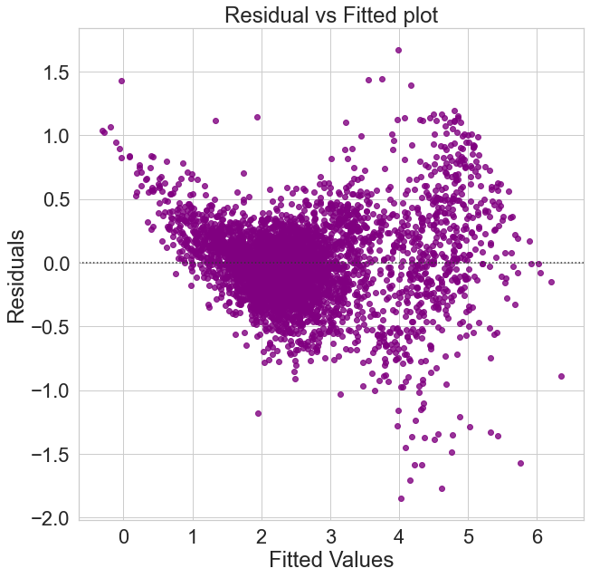

```python
sns.set_style("whitegrid")
plt.figure(figsize=(10, 10))
sns.residplot(fittedl, residuall, color="purple", lowess=False)
plt.xlabel("Fitted Values")
plt.ylabel("Residuals")
plt.title("Residual vs Fitted plot")
plt.show()
```

# Test for normality

### Error terms/Residuals normally distributed

Even though deviations were reduced, shapiro test failed.

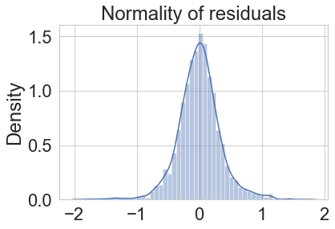

```python
sns.distplot(residuall)
plt.title("Normality of residuals")
plt.show()
```

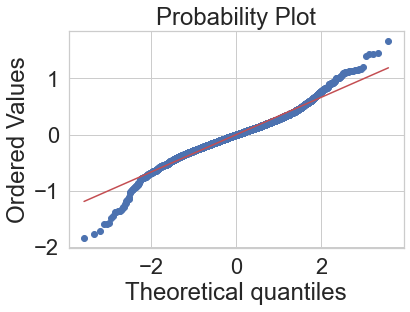

```python
import pylab
import scipy.stats as stats

stats.probplot(residuall, dist="norm", plot=pylab)
plt.show()
```

```python
stats.shapiro(residuall)
```

```
ShapiroResult(statistic=0.9695791602134705, pvalue=3.403133859913044e-28)
```

As the previous data test, the residuals are not normal as per shapiro test, but as per QQ plot and distplot they are approximately normal. Hence we go with the plots and say that residuals are normal.

# Test for Homoscedasticity

```python
import statsmodels.stats.api as sms
from statsmodels.compat import lzip

name = ["F statistic", "p-value"]
test = sms.het_goldfeldquandt(residuall, Xl_train1)
lzip(name, test)
```

```
[('F statistic', 0.9771697386513875), ('p-value', 0.6943711943091961)]
```

Since p-value > 0.05, we can say that the residuals are homoscedastic (variance of the residuals are symmetrically distributed across the regression line). This assumption is therefore valid in the data.

# Predicting on the test data with sqrt transformation & final conclusions

Since our initial model did not change, we will use the results provided in the OLS Summary to do our conclusions.

First let me remind that there are a lot of boundries for this Model. The Min and Max values in the Data set shall be respected while making predictions about Prices.

If you want to calculate the price of a used car from 1990, you better not use this model, because the min value in years is 1998. For car 'age' (Years column) you have a range of 20 years to use, but anything above or below will not achieve the accuracy described above. The Company has to take a risk using this model.

The same goes for the Brands, if you want to calculate the Price of Porsche or Smart, this model is not the best fit. Since we have no observation on those Brands. As long as the calculations stick to the 'assumptions', the model 'garantees' the accuracy around 90%, otherwise, your 'accuracy' will decrease.

```python
cars_Log.describe()
```

|  | Year | Kilometers_Driven | Mileage | Engine | Power | Seats | Price | Pricesqrt | KDsqrt | MILsqrt | Pwsqrt |
| --- | --- | --- | --- | --- | --- | --- | --- | --- | --- | --- | --- |
| count | 5658.000000 | 5658.000000 | 5658.000000 | 5658.000000 | 5658.000000 | 5658.000000 | 5658.000000 | 5658.000000 | 5658.000000 | 5658.000000 | 5658.000000 |
| mean | 2013.316366 | 57536.017497 | 18.306490 | 1576.045422 | 107.979989 | 5.284730 | 7.969776 | 2.605750 | 229.847043 | 4.234645 | 10.197958 |
| std | 3.237620 | 32921.301832 | 4.360687 | 533.488655 | 44.011398 | 0.782329 | 7.181786 | 1.086301 | 68.608937 | 0.611835 | 1.995583 |
| min | 1998.000000 | 171.000000 | 0.000000 | 624.000000 | 34.200000 | 2.000000 | 0.440000 | 0.663325 | 13.076697 | 0.000000 | 5.848077 |
| 25% | 2011.000000 | 34912.750000 | 15.500000 | 1197.000000 | 75.000000 | 5.000000 | 3.500000 | 1.870829 | 186.849529 | 3.937004 | 8.660254 |
| 50% | 2014.000000 | 54000.000000 | 18.500000 | 1461.000000 | 91.100000 | 5.000000 | 5.500000 | 2.345208 | 232.379001 | 4.301163 | 9.544632 |
| 75% | 2016.000000 | 73500.000000 | 21.100000 | 1968.000000 | 126.320000 | 5.000000 | 9.150000 | 3.024897 | 271.108834 | 4.593474 | 11.239217 |
| max | 2019.000000 | 248000.000000 | 28.400000 | 4134.000000 | 335.200000 | 10.000000 | 37.900000 | 6.156298 | 497.995984 | 5.329165 | 18.308468 |

```python
cars_Log.Brand.value_counts()
```

```
Maruti           1141
Hyundai          1088
Honda             600
Toyota            400
Volkswagen        313
Ford              295
Mahindra          271
Mercedes-Benz     245
BMW               214
Audi              196
Tata              183
Skoda             171
Renault           145
Chevrolet         121
Nissan             91
Land-Rover         32
Mitsubishi         27
Jaguar             26
Mini               25
Fiat               25
Volvo              21
Jeep               15
Datsun             13
Name: Brand, dtype: int64
```

# Conclusions

Aware of the given Warnings, it is possible to conclude:

We need to square the coeficients, because the model was square rooted.

- Year, Power and Seats are the individual attributes that increase the price of the car

The attribute Year has a coef of 0.1329 , hence the price of the car increases by 0.1329² = 0.01766 for any increase in the year. Which is reasonable, because younger cars, have higher values.

- Transmission_Manual, Owner second and third are individual attributes (X) that decrease the price of the car (y)

For every 1 unit increase in X, Y will dencrease by X Coef² in Lakhs.

- Dummy variables also have coeficientes that follow the same logic, which in some case would mean that certain car models and cities have positive effect on the price. Using these coeficientes, the company can position itself on the market with more accuracy and profitability.